# R

### 김동민

# 저는 평범한 학생입니다.

### 빅데이터학과

# 빅데이터학과에서는 데이터를 다룹니다.

### 좋아하는 것들

- 친구
  - 승훈이형
- 애착 물건
  - 컴퓨터
- 음식
  - 국밥

### 사진

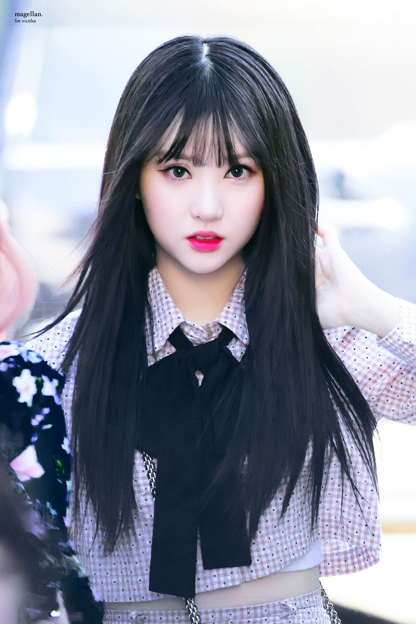

### 자료분석

### 지도 관련 패키지 설치 및 불러오기

# + 공간 지도 분석을 위한 패키지

# - maps: 세계 지도 데이터베이스

# - mapproj: 지도 상에 위도와 경도를 표시

# - ggplot2: map_data()를 이용하여 지도정보를 R로 불러오기

# - ggiraphExtra : 단계 구분도 표시

install.packages(“maps”) install.packages(“mapproj”) install.packages(“ggiraphExtra”)

library(maps) library(mapproj) library(ggplot2) library(ggiraphExtra)

### kormap2패키지 : 2014년 한국 행정 지도 (시군구별) 데이터

# [참고] https://rstudio-pubs-static.s3.amazonaws.com/222145_fdcc8a5cb9584950ae7e8097304bf398.html

install.packages(“devtools”) update.packages(checkBuilt=TRUE) devtools::install_github(“cardiomoon/kormaps2014”) library(kormaps2014)

# 한국의 행정지도를 그리기 위한 패키지 불러오기

library(kormaps2014) # 한국행정지도 데이터 # kormap1 : 2014년 한국행정지도(시도별) # kormap2 : 2014년 한국행정지도(시군구별) # kormap3 : 2014년 한국행정지도(읍면동별) library(ggplot2) # 그래프 그리기 library(ggiraphExtra) # 단계구분도 작성

library(dplyr) library(stringr)

### 지도 관련 패키지 설치 및 불러오기

# + 공간 지도 분석을 위한 패키지

# - maps: 세계 지도 데이터베이스

# - mapproj: 지도 상에 위도와 경도를 표시

# - ggplot2: map_data()를 이용하여 지도정보를 R로 불러오기

# - ggiraphExtra : 단계 구분도 표시